# Quality control (QC) and filtering

The purpose of this Notebook is to

- check the quality of the data
- filter out cells that don't match the quality criteria.

## Input data and configuration

```python
input_file = "../results/01_process_data/adata.h5ad"
output_file = "tmp/adata.h5ad"
table_dir = "../tables"
```

```python
# Parameters
input_file = "input_adata.h5ad"
output_file = "adata.h5ad"
table_dir = "tables"
```

```python
%load_ext autoreload
%autoreload 2

import numpy as np
import scanpy as sc
import pandas as pd
from matplotlib import pyplot as plt
import seaborn as sns
import os
import scirpy as ir

import sys

sys.path.extend(("lib", "../lib"))

from jupytertools import *

fix_logging(sc.settings)
```

```python
mito_genes = pd.read_csv(os.path.join(table_dir, "mitochondrial_genes.tsv"), sep="\t")[
    "Gene name"
].values
biomart = pd.read_csv(os.path.join(table_dir, "biomart.tsv"), sep="\t")
ribo_genes = pd.read_csv(
    os.path.join(table_dir, "ribosomal_genes.tsv"), sep="\t", comment="#"
)["Approved symbol"].values
```

```python
adata = sc.read_h5ad(input_file)
```

```python
print(adata)
```

[output not shown]

```python
def compute_quality_metrics(adata):
    tmp_mito = [g for g in mito_genes if g in adata.var_names]
    adata.obs["mt_frac"] = np.sum(adata[:, tmp_mito].X, axis=1) / np.sum(
        adata.X, axis=1
    )
    adata.obs["n_counts"] = adata.X.sum(axis=1)
    adata.obs["n_genes"] = (adata.X != 0).sum(axis=1)
    adata.obs["rk_n_counts"] = adata.obs["n_counts"].rank(
        ascending=False, method="first"
    )
    adata.obs["rk_n_genes"] = adata.obs["n_genes"].rank(ascending=False, method="first")
    adata.obs["rk_mt_frac"] = adata.obs["mt_frac"].rank(ascending=True, method="first")
```

# Quality Metrics

Quality control follows the new "Best practice" tutorial for single cell analysis [(Luecken & Theis 2019)](https://www.embopress.org/doi/full/10.15252/msb.20188746) and the accompanying [case study notebook](https://github.com/theislab/single-cell-tutorial/blob/master/latest_notebook/Case-study_Mouse-intestinal-epithelium_1906.ipynb).

```python
MIN_COUNTS = 2000
MIN_GENES = 700
MAX_MITO = 0.11
MIN_CELLS = 50
DOUBLET_THRES = 0.4
```

```python
assert adata.var_names.is_unique
```

Coarse filtering to reduce amount of data:

```python
sc.pp.filter_cells(adata, min_genes=100)
compute_quality_metrics(adata)
print_dim(adata)
```

```
Current dimensions of adata: 71401 cells x 33514 genes.
```

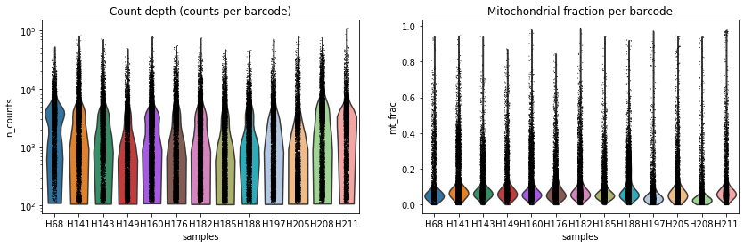

```python
fig, (ax1, ax2) = plt.subplots(1, 2, figsize=(14, 4))
sc.pl.violin(adata, "n_counts", groupby="samples", log=True, cut=0, ax=ax1, show=False)
sc.pl.violin(adata, "mt_frac", groupby="samples", ax=ax2, show=False)
ax1.set_title("Count depth (counts per barcode)")
ax2.set_title("Mitochondrial fraction per barcode")
fig.show()
os.makedirs("./tmp", exist_ok=True)
fig.savefig("./tmp/qc_dist_per_sample_before.png")
```

The sample quality looks sufficiently consistent, so that we apply global filtering cut-offs instead of per-sample filtering

## Gene level filtering

Filter genes that occur in less than MIN_CELLS of cells. Relates to the minimal expected cluster size. Given the number of cells, I expect the smallest cluster of interest to contain at least 50 cells.

```python
sc.pp.filter_genes(adata, min_cells=MIN_CELLS)
print_dim(adata)
```

```
filtered out 16522 genes that are detected in less than 50 cells
```

```
Current dimensions of adata: 71401 cells x 16992 genes.
```

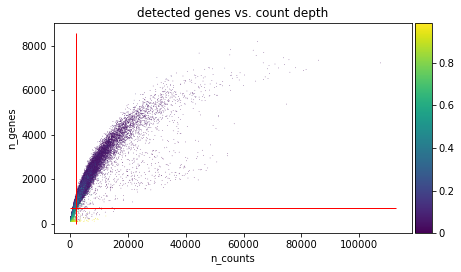

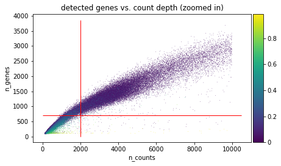

```python
ax1 = sc.pl.scatter(
    adata,
    x="n_counts",
    y="n_genes",
    color="mt_frac",
    title="detected genes vs. count depth",
    show=False,
)
ax1.hlines(y=MIN_GENES, xmin=0, xmax=ax1.get_xlim()[1], linewidth=1, color="red")
ax1.vlines(x=MIN_COUNTS, ymin=0, ymax=ax1.get_ylim()[1], linewidth=1, color="red")
plt.show()

ax2 = sc.pl.scatter(
    adata[adata.obs["n_counts"] < 10000],
    x="n_counts",
    y="n_genes",
    color="mt_frac",
    title="detected genes vs. count depth (zoomed in)",
    show=False,
)
ax2.hlines(y=MIN_GENES, xmin=0, xmax=ax2.get_xlim()[1], linewidth=1, color="red")
ax2.vlines(x=MIN_COUNTS, ymin=0, ymax=ax2.get_ylim()[1], linewidth=1, color="red")
plt.show()
```

## Count depth and detected genes

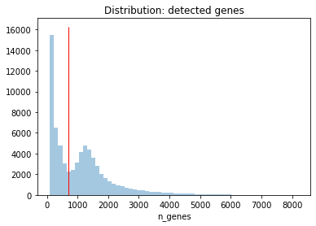

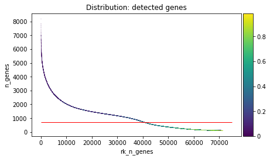

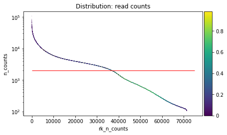

```python
ax1 = sns.distplot(adata.obs["n_genes"], kde=False, bins=60)
ax1.set_title("Distribution: detected genes")
ax1.vlines(x=MIN_GENES, color="red", linewidth=1, ymin=0, ymax=ax1.get_ylim()[1])
plt.show()

ax2 = sc.pl.scatter(
    adata,
    x="rk_n_genes",
    y="n_genes",
    color="mt_frac",
    legend_loc="none",
    title="Distribution: detected genes",
    show=False,
)
ax2.hlines(y=MIN_GENES, color="red", linewidth=1, xmin=0, xmax=ax2.get_xlim()[1])
plt.show()

ax3 = sc.pl.scatter(
    adata,
    x="rk_n_counts",
    y="n_counts",
    color="mt_frac",
    legend_loc="none",
    title="Distribution: read counts",
    show=False,
)
ax3.hlines(y=MIN_COUNTS, color="red", linewidth=1, xmin=0, xmax=ax3.get_xlim()[1])
ax3.set_yscale("log")
plt.show()
```

## Mitochondrial reads

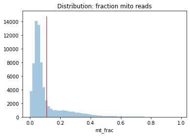

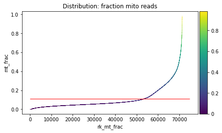

```python
ax4 = sns.distplot(adata.obs["mt_frac"], kde=False, bins=60)
ax4.set_title("Distribution: fraction mito reads")
ax4.vlines(x=MAX_MITO, color="red", linewidth=1, ymin=0, ymax=ax4.get_ylim()[1])
plt.show()

ax5 = sc.pl.scatter(
    adata,
    x="rk_mt_frac",
    y="mt_frac",
    color="mt_frac",
    show=False,
    legend_loc="none",
    title="Distribution: fraction mito reads",
)
ax5.hlines(y=MAX_MITO, color="red", linewidth=1, xmin=0, xmax=ax5.get_xlim()[1])
plt.show()
```

# Apply filtering by quality metrics

```python
print_dim(adata)
```

```
Current dimensions of adata: 71401 cells x 16992 genes.
```

Apply `MIN_GENES` threshold:

```python
sc.pp.filter_cells(adata, min_genes=MIN_GENES)
print_dim(adata)
```

```
filtered out 30847 cells that have less than 700 genes expressed
Current dimensions of adata: 40554 cells x 16992 genes.
```

Apply `MIN_COUNTS` threshold:

```python
sc.pp.filter_cells(adata, min_counts=MIN_COUNTS)
print_dim(adata)
```

```
filtered out 3793 cells that have less than 2000 counts
Current dimensions of adata: 36761 cells x 16992 genes.
```

Apply `MAX_MITO` threshold:

```python
adata = adata[adata.obs["mt_frac"] < MAX_MITO, :]
print_dim(adata)
```

```
Current dimensions of adata: 35052 cells x 16992 genes.
```

### exclude ribosomal and mitochondrial genes

Ribosomal genes were downloaded from https://www.genenames.org/data/genegroup/#!/group/1054

```python
adata = adata[:, ~adata.var_names.isin(np.append(mito_genes, ribo_genes))]
print_dim(adata)
```

```
Current dimensions of adata: 35052 cells x 16818 genes.
```

### QC plots after filtering

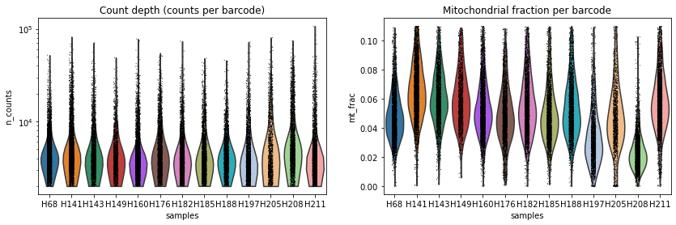

```python
fig, (ax1, ax2) = plt.subplots(1, 2, figsize=(14, 4))
sc.pl.violin(adata, "n_counts", groupby="samples", log=True, cut=0, ax=ax1, show=False)
sc.pl.violin(adata, "mt_frac", groupby="samples", ax=ax2, show=False)
ax1.set_title("Count depth (counts per barcode)")
ax2.set_title("Mitochondrial fraction per barcode")
fig.show()
fig.savefig("./tmp/qc_dist_per_sample_after.png")
```

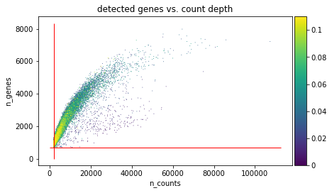

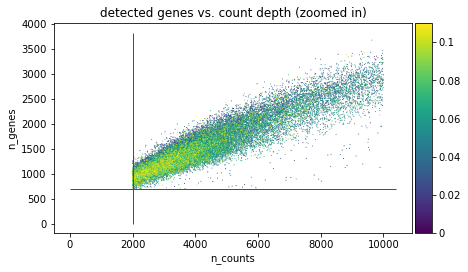

```python
ax1 = sc.pl.scatter(
    adata,
    x="n_counts",
    y="n_genes",
    color="mt_frac",
    title="detected genes vs. count depth",
    show=False,
)
ax1.hlines(y=MIN_GENES, xmin=0, xmax=ax1.get_xlim()[1], linewidth=1, color="red")
ax1.vlines(x=MIN_COUNTS, ymin=0, ymax=ax1.get_ylim()[1], linewidth=1, color="red")
plt.show()

ax2 = sc.pl.scatter(
    adata[adata.obs["n_counts"] < 10000],
    x="n_counts",
    y="n_genes",
    color="mt_frac",
    title="detected genes vs. count depth (zoomed in)",
    show=False,
)
ax2.hlines(y=MIN_GENES, xmin=0, xmax=ax2.get_xlim()[1], linewidth=1, color="red")
ax2.vlines(x=MIN_COUNTS, ymin=0, ymax=ax2.get_ylim()[1], linewidth=1, color="red")
plt.show()
```

## Immune-receptor-based filtering

We leverate TCR receptor sequencing data to call putative doublets. Cells with more than one TCR-beta or more than two TCR-alpha chains are removed.

```python
ir.tl.chain_qc(adata)
```

```
Trying to set attribute `.obs` of view, copying.
```

```
... storing 'receptor_type' as categorical
... storing 'receptor_subtype' as categorical
... storing 'chain_pairing' as categorical
```

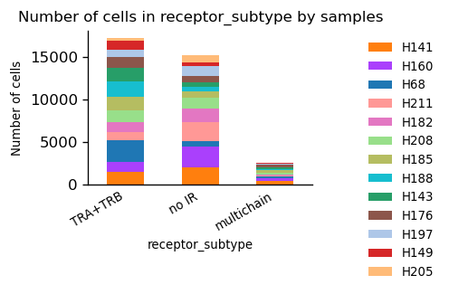

```python
ir.pl.group_abundance(adata, groupby="receptor_subtype", target_col="samples")
```

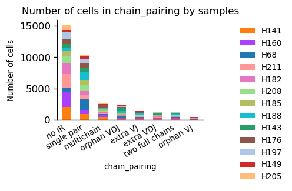

```python
ir.pl.group_abundance(adata, groupby="chain_pairing", target_col="samples")
```

Remove multichain cells and extra VDJ (=beta) cells. extra VJ (=alpha) is ok, as T-cells can have two alpha chains.

```python
tcr_filter = adata.obs["chain_pairing"].isin(
    ["multichain", "extra VDJ", "two full chains"]
)
print_dim(adata)
adata = adata[~tcr_filter, :].copy()
print_dim(adata)
```

```
Current dimensions of adata: 35052 cells x 16818 genes.
Current dimensions of adata: 29843 cells x 16818 genes.
```

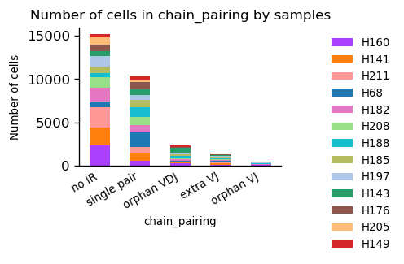

```python
ir.pl.group_abundance(adata, groupby="chain_pairing", target_col="samples")
```

# UMAP plot by covariates

```python
## Normalize (for visualization only, we will save the raw counts!)
# sc.pp.filter_genes(adata, min_cells=1)
adata_vis = adata.copy()
sc.pp.normalize_per_cell(adata_vis, counts_per_cell_after=1e4)
sc.pp.log1p(adata_vis)
sc.pp.filter_genes(adata_vis, min_cells=1)
```

```
normalizing by total count per cell
    finished ({time_passed}): normalized adata.X and added    'n_counts', counts per cell before normalization (adata.obs)
```

```python
sc.tl.pca(adata_vis, svd_solver="arpack")
sc.pp.neighbors(adata_vis, n_neighbors=10, n_pcs=40)
sc.tl.umap(adata_vis)
```

```
computing PCA
    with n_comps=50
    finished
computing neighbors
    using 'X_pca' with n_pcs = 40
    finished
computing UMAP
    finished
```

```python
sc.tl.leiden(adata_vis)
```

```
running Leiden clustering
    finished
```

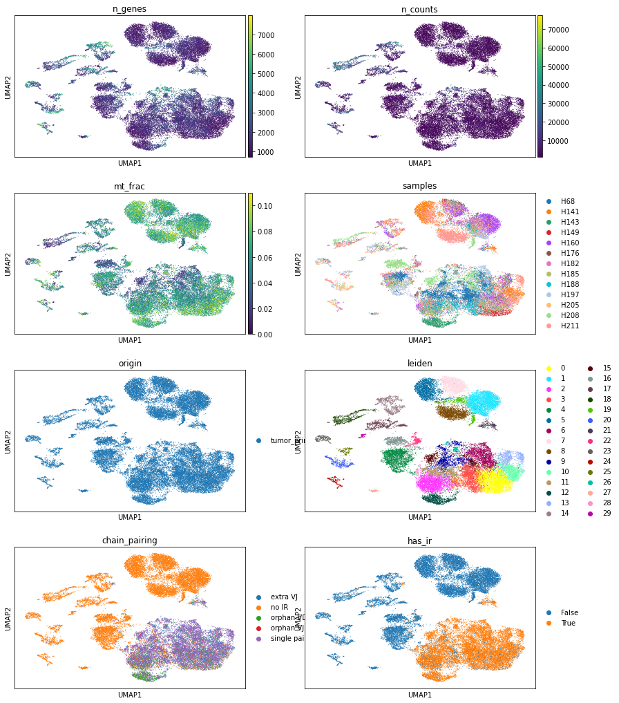

```python
sc.pl.umap(
    adata_vis,
    color=[
        "n_genes",
        "n_counts",
        "mt_frac",
        "samples",
        "origin",
        "leiden",
        "chain_pairing",
        "has_ir",
    ],
    ncols=2,
)
```

# save result

```python
adata.write(output_file, compression="lzf")
```